# ggplot2 examples and exercises

### Theme

Theming defines the feel and look of your final visualisation and is something you will normally defer to the final polishing of the plot. It is very easy to change looks with a prebuild theme

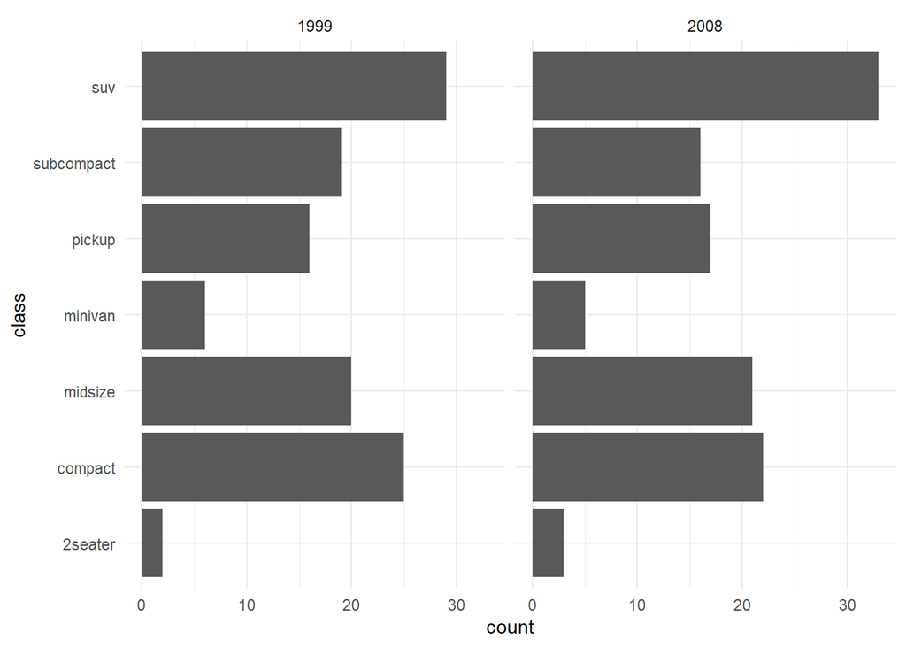

```r
ggplot(mpg) +
  geom_bar(aes(y = class)) +
  facet_wrap(~year) +
  theme_minimal()
```

Further adjustments can be done in the end to get exactly the look you want

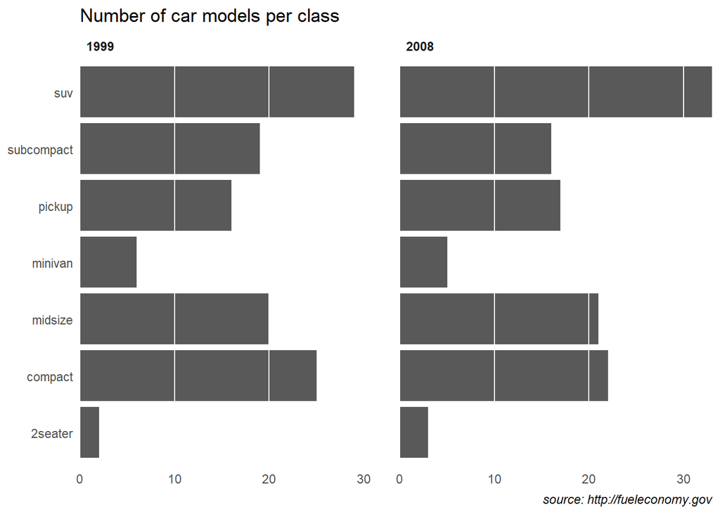

```r
ggplot(mpg) +
  geom_bar(aes(y = class)) +
  facet_wrap(~year) +
  labs(title = "Number of car models per class",
       caption = "source: http://fueleconomy.gov",
       x = NULL,
       y = NULL) +
  scale_x_continuous(expand = c(0, NA)) +
  theme_minimal() +
  theme(
    text = element_text('Avenir Next Condensed'),
    strip.text = element_text(face = 'bold', hjust = 0),
    plot.caption = element_text(face = 'italic'),
    panel.grid.major = element_line('white', size = 0.5),
    panel.grid.minor = element_blank(),
    panel.grid.major.y = element_blank(),
    panel.ontop = TRUE
  )
```

#### Exercises

Themes can be overwhelming, especially as you often try to optimise for beauty while you learn. To remove the last part of the equation, the exercise is to take the plot given below and make it as hideous as possible using the theme function. Go absolutely crazy, but take note of the effect as you change different settings.

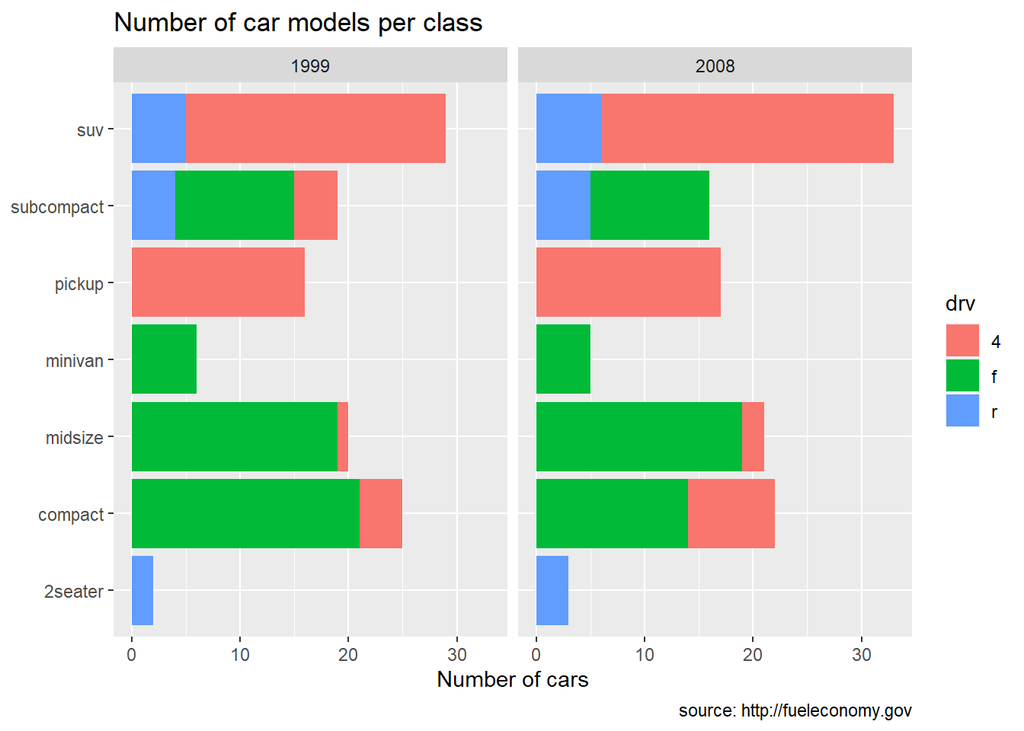

```r
ggplot(mpg) +
  geom_bar(aes(y = class, fill = drv)) +
  facet_wrap(~year) +
  labs(title = "Number of car models per class",
       caption = "source: http://fueleconomy.gov",
       x = 'Number of cars',
       y = NULL)
```

## Extensions

While ggplot2 comes with a lot of batteries included, the extension ecosystem provides priceless additinal features

### Plot composition

We start by creating 3 separate plots

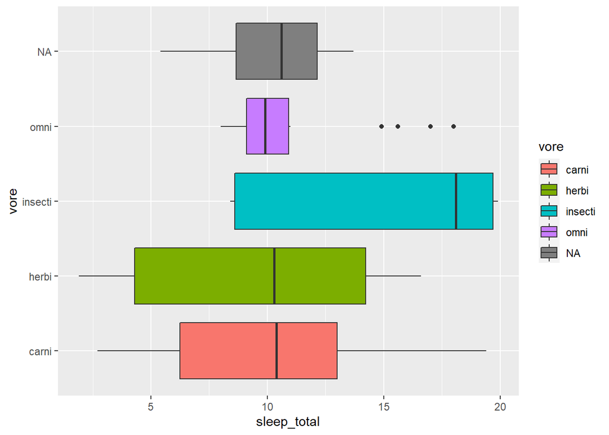

```r
p1 <- ggplot(msleep) +
  geom_boxplot(aes(x = sleep_total, y = vore, fill = vore))
p1
```

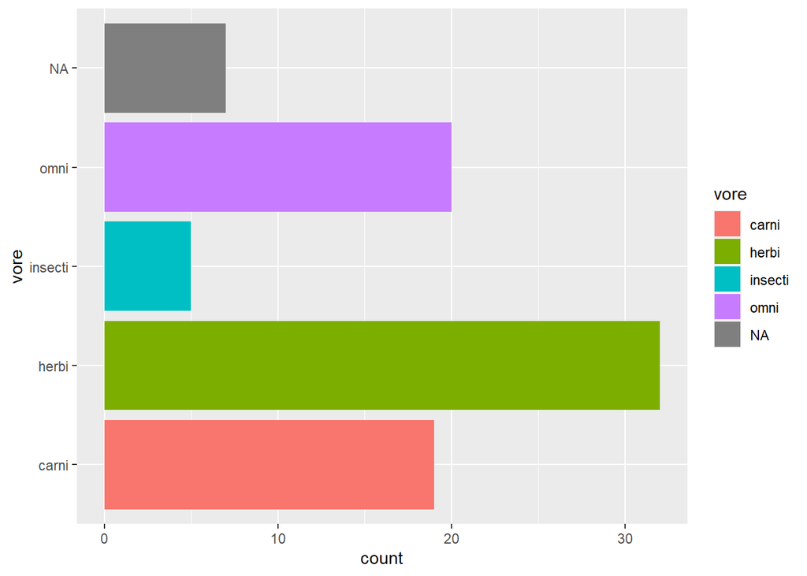

```r
p2 <- ggplot(msleep) +
  geom_bar(aes(y = vore, fill = vore))
p2
```

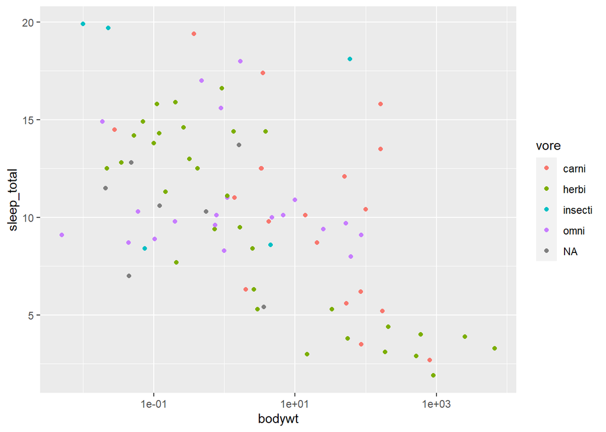

```r
p3 <- ggplot(msleep) +
  geom_point(aes(x = bodywt, y = sleep_total, colour = vore)) +
  scale_x_log10()
p3
```

Combining them with patchwork is a breeze using the different operators

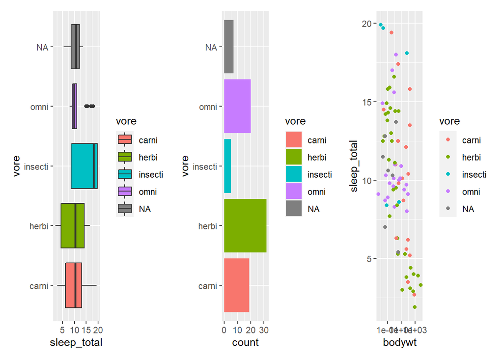

```r
library(patchwork)
p1 + p2 + p3
```

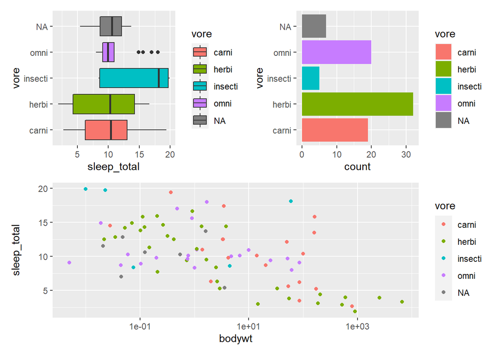

```r
(p1 | p2) /
   p3
```

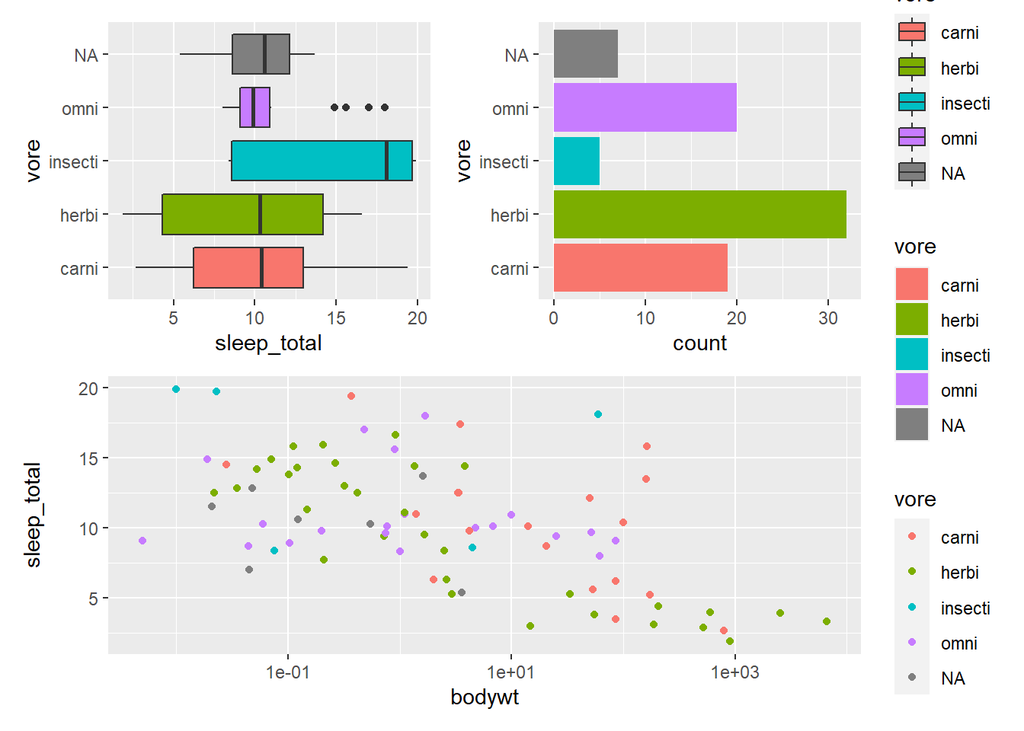

```r
p_all <- (p1 | p2) /
            p3
p_all + plot_layout(guides = 'collect')
```

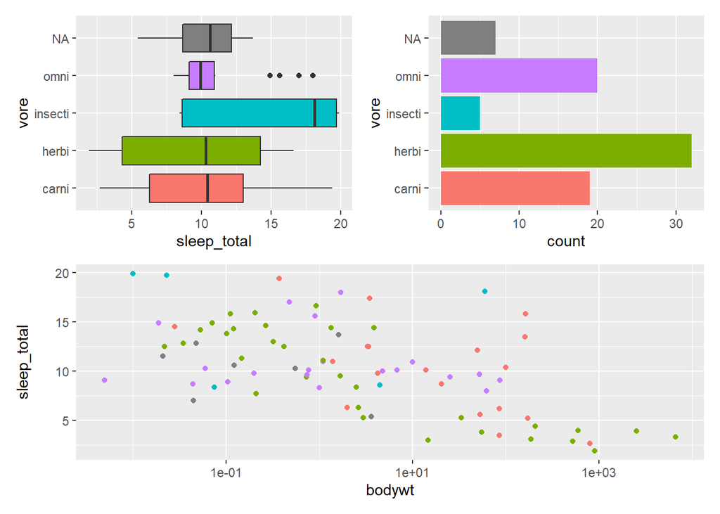

```r
p_all & theme(legend.position = 'none')
```

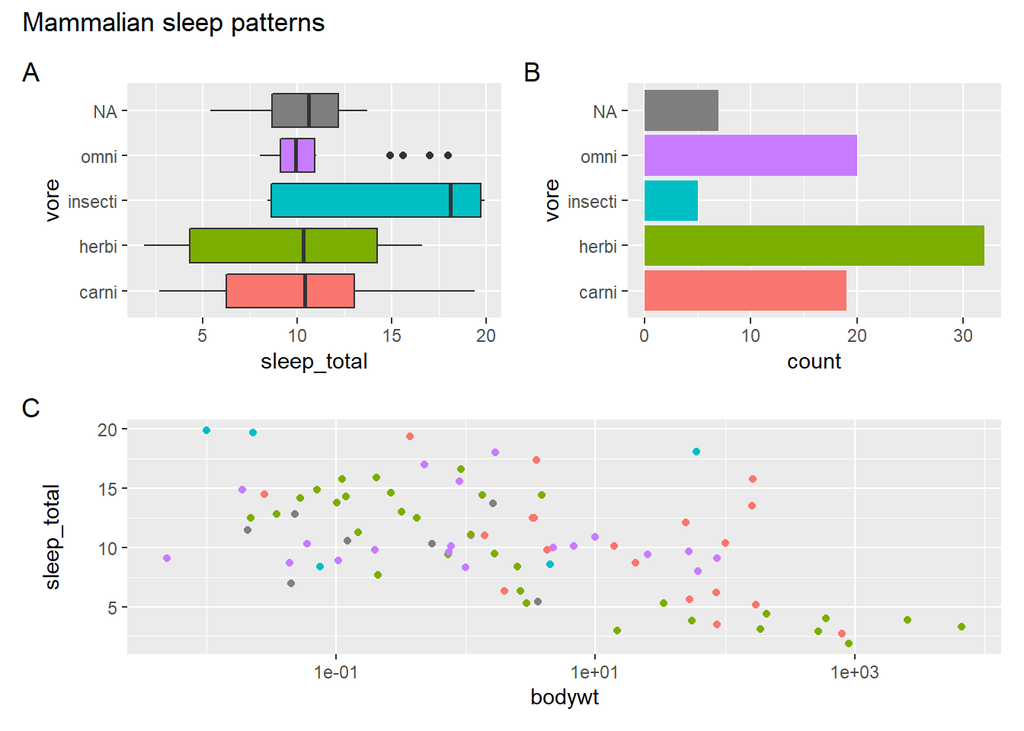

```r
p_all <- p_all & theme(legend.position = 'none')
p_all + plot_annotation(
  title = 'Mammalian sleep patterns',
  tag_levels = 'A'
)
```

#### Excercises

Patchwork will assign the same amount of space to each plot by default, but this can be controlled with the `widths` and `heights` argument in `plot_layout()`. This can take a numeric vector giving their relative sizes (e.g. `c(2, 1)` will make the first plot twice as big as the second). Modify the code below so that the middle plot takes up half of the total space:

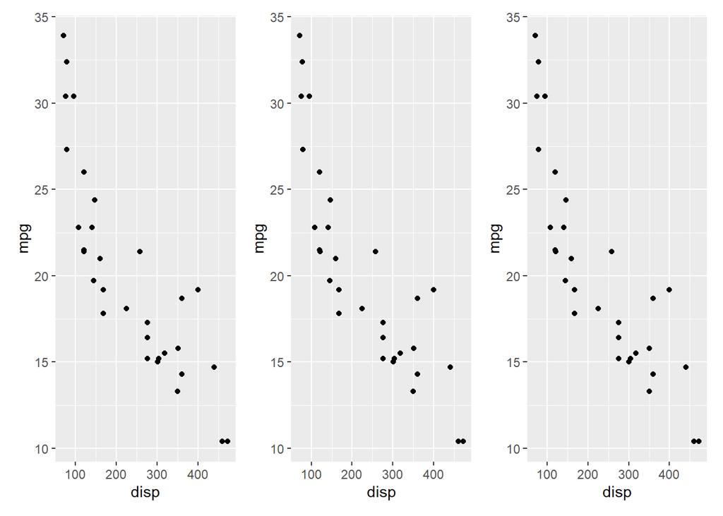

```r
p <- ggplot(mtcars) +
  geom_point(aes(x = disp, y = mpg))
p + p + p
```

The `&` operator can be used with any type of ggplot2 object, not just themes. Modify the code below so the two plots share the same y-axis (same limits)

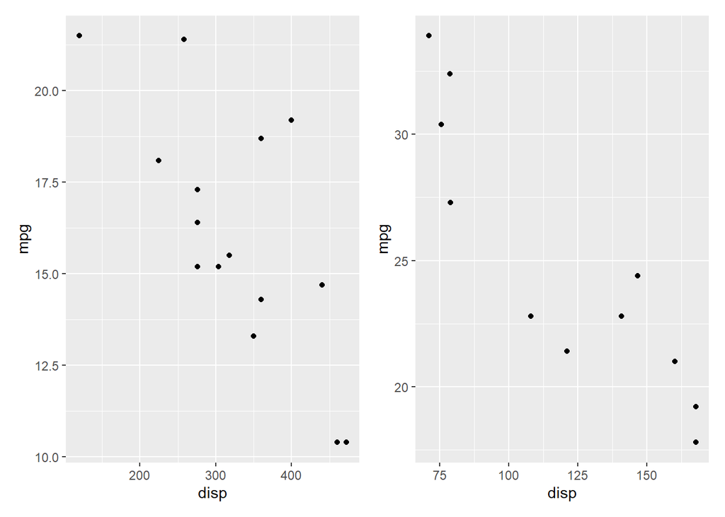

```r
p1 <- ggplot(mtcars[mtcars$gear == 3,]) +
  geom_point(aes(x = disp, y = mpg))
p2 <- ggplot(mtcars[mtcars$gear == 4,]) +
  geom_point(aes(x = disp, y = mpg))
p1 + p2
```

Patchwork contains many features for fine tuning the layout and annotation. Very complex layouts can be obtained by providing a design specification to the `design` argument in `plot_layout()`. The design can be defined as a textual representation of the cells. Use the layout given below. How should the textual representation be undertood.

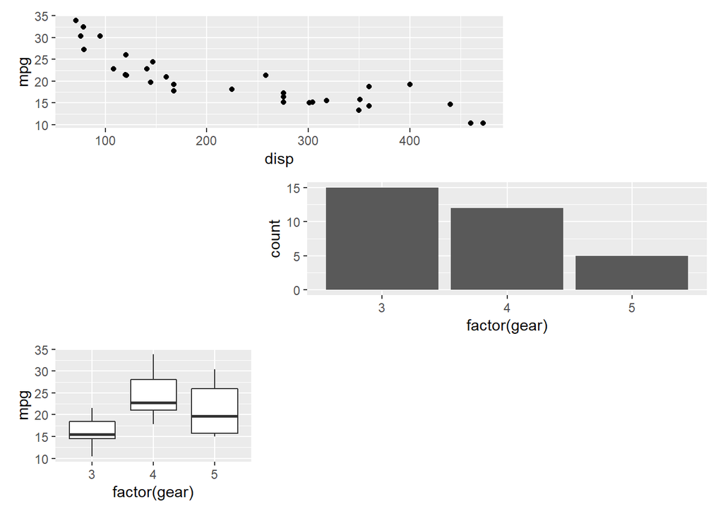

```r
p1 <- ggplot(mtcars) +
  geom_point(aes(x = disp, y = mpg))
p2 <- ggplot(mtcars) +
  geom_bar(aes(x = factor(gear)))
p3 <- ggplot(mtcars) +
  geom_boxplot(aes(x = factor(gear), y = mpg))
layout <- '
AA#
#BB
C##
'
p1 + p2 + p3 + plot_layout(design = layout)
```